# Lectures 5 & 6 — Multi-State Life Tables

Author

Dr Belen Zapata-Diomedi, IMS Epidemiology Unit

Published

March 20, 2026

# 1 Data and Functions

Here we load the libraries, source the helper functions, and read all required data.

```r
library(ggplot2)
library(readr)
library(dplyr)
library(tidyr)

# ── Helper functions (RunLifeTable, assignPA_RRs, calculate_pif) ───────────────
source("functions.R")

# ── Output directory ───────────────────────────────────────────────────────────
dir.create("outputs/lecture_5_6", recursive = TRUE, showWarnings = FALSE)
```

## 1.1 MSLT data (Colombia)

The MSLT data file contains one row per age (0–100) and sex, with all-cause mortality rates (`mx`), disability weights (`pyld_rate`), population size, and disease-specific parameters for Colombia. All rates are derived from GBD 2023 Colombia estimates.

```r
mslt_general <- read_csv("data/lecture_5_6/mslt_colombia.csv") #(CHANGE for final file)

glimpse(mslt_general)
```

```
Rows: 202
Columns: 31
$ age                <dbl> 0, 1, 2, 3, 4, 5, 6, 7, 8, 9, 10, 11, 12, 13, 14, 1…
$ sex                <chr> "female", "female", "female", "female", "female", "…
$ age_sex            <chr> "0_female", "1_female", "2_female", "3_female", "4_…
$ population         <dbl> 0, 0, 0, 0, 0, 0, 0, 0, 0, 0, 0, 0, 0, 0, 0, 0, 0, …
$ mx                 <dbl> 0.0002427714, 0.0002516049, 0.0002607598, 0.0002702…
$ pyld_rate          <dbl> 0.04949699, 0.05123252, 0.05302889, 0.05488826, 0.0…
$ deaths_rate_ishd   <dbl> 0, 0, 0, 0, 0, 0, 0, 0, 0, 0, 0, 0, 0, 0, 0, 0, 0, …
$ ylds_rate_ishd     <dbl> 1.740210e-06, 2.094805e-06, 2.521654e-06, 3.035480e…
$ dw_adj_ishd        <dbl> 0, 0, 0, 0, 0, 0, 0, 0, 0, 0, 0, 0, 0, 0, 0, 0, 0, …
$ prevalence_ishd    <dbl> 0, 0, 0, 0, 0, 0, 0, 0, 0, 0, 0, 0, 0, 0, 0, 0, 0, …
$ deaths_rate_strk   <dbl> 0, 0, 0, 0, 0, 0, 0, 0, 0, 0, 0, 0, 0, 0, 0, 0, 0, …
$ ylds_rate_strk     <dbl> 9.035675e-05, 9.487621e-05, 9.962173e-05, 1.046046e…
$ dw_adj_strk        <dbl> 0, 0, 0, 0, 0, 0, 0, 0, 0, 0, 0, 0, 0, 0, 0, 0, 0, …
```

[output cut: 18 more lines]

## 1.2 Bogotá population data

This file contains the Bogotá study population with marginal MET-hours per week drawn from sex-specific log-normal distributions, plus a counterfactual scenario (`mmet_scen = mmet_ref + 2`). It was prepared in Lecture 3.

```r
bogota_mmets <- read_csv("data/lecture_5_6/base_pop_bogota_ph.csv")

bogota_mmets %>%
  pivot_longer(
    cols      = c(mmet_ref, mmet_scen),
    names_to  = "scenario",
    values_to = "mmet"
  ) %>%
  mutate(scenario = ifelse(scenario == "mmet_ref",
                           "Reference", "Scenario (+2 mMETs)")) %>%
  group_by(sex, scenario) %>%
  summarise(
    n      = n(),
    min    = round(min(mmet,             na.rm = TRUE), 2),
    q1     = round(quantile(mmet, 0.25,  na.rm = TRUE), 2),
    median = round(median(mmet,          na.rm = TRUE), 2),
    mean   = round(mean(mmet,            na.rm = TRUE), 2),
    q3     = round(quantile(mmet, 0.75,  na.rm = TRUE), 2),
    max    = round(max(mmet,             na.rm = TRUE), 2),
    .groups = "drop"
  )
```

```
# A tibble: 4 × 9
  sex    scenario                n   min    q1 median  mean    q3   max
  <chr>  <chr>               <int> <dbl> <dbl>  <dbl> <dbl> <dbl> <dbl>
1 female Reference           55593  0.13  5.51   10.7  17.4  20.9  675.
2 female Scenario (+2 mMETs) 55593  2.13  7.51   12.7  19.4  22.9  677.
3 male   Reference           52825  0.09  5.2    10.7  18.6  21.8 1230.
4 male   Scenario (+2 mMETs) 52825  2.09  7.2    12.7  20.6  23.8 1232.
```

# 2 Life Table Structure and Variables

A **cohort life table** tracks a group of people born (or entering an age) at the same time and follows them as they age and die. Each row represents one year of age.

| Variable | Meaning |
| --- | --- |
| `mx` | All-cause mortality *rate* at age x (deaths per person-year) |
| `qx` | Probability of dying between age x and x+1 |
| `lx` | Number of survivors at age x |
| `dx` | Number who die between age x and x+1 |
| `Lx` | Person-years lived by the cohort between age x and x+1 |
| `ex` | Remaining life expectancy at age x |
| `pyld_rate` | All-cause disability weight (proportion of health lost) |
| `Lwx` | Health-adjusted person-years lived (Lx × (1 − pyld_rate)) |
| `ewx` | Health-adjusted life expectancy at age x |

The key relationships are:

$$q_x = 1 - e^{-m_x}$$

$$L_x = \frac{l_x + l_{x+1}}{2}$$

$$e_x = \frac{\sum_{t=x}^{100} L_t}{l_x}$$

## 2.1 Reference life table (no trend)

We work with **50–54-year-old females** (mid-age = 52) throughout. Change `in_sex` and `in_mid_age` to explore other cohorts.

Available mid-ages: 17, 22, 27, 32, 37, 42, 47, **52**, 57, 62, 67, 72, 77, 82, 87, 92, 97

```r
lt_ref <- RunLifeTable(
  in_data    = mslt_general,
  in_sex     = "female",
  in_mid_age = 52,
  mx_trend   = NA,   # NA = no trend, use static mx
  scenario   = 0     # 0 = no PIF-based reduction
) %>%
  mutate(label = "Reference (no trend)")

write_csv(lt_ref, "outputs/lecture_5_6/life_table_reference.csv")

lt_ref %>%
  select(age, mx, qx, lx, dx, Lx, ex, Lwx, ewx) %>%
  head(10)
```

```
# A tibble: 10 × 9
     age      mx      qx       lx    dx       Lx    ex      Lwx   ewx
   <dbl>   <dbl>   <dbl>    <dbl> <dbl>    <dbl> <dbl>    <dbl> <dbl>
 1    52 0.00257 0.00257 1505839. 3870. 1503904.  33.6 1250188.  26.0
 2    53 0.00277 0.00277 1501969. 4158. 1499890.  32.7 1244459.  25.3
 3    54 0.00300 0.00299 1497811. 4483. 1495570.  31.8 1238569.  24.5
 4    55 0.00325 0.00324 1493328. 4842. 1490907.  30.9 1232419.  23.8
 5    56 0.00352 0.00352 1488486. 5234. 1485869.  30.0 1225911.  23.0
 6    57 0.00382 0.00381 1483252. 5652. 1480426.  29.1 1218947.  22.3
 7    58 0.00413 0.00412 1477600. 6092. 1474554.  28.2 1211574.  21.5
 8    59 0.00447 0.00446 1471507. 6561. 1468227.  27.3 1203824.  20.8
 9    60 0.00484 0.00483 1464946. 7069. 1461412.  26.4 1195568.  20.1
10    61 0.00525 0.00523 1457878. 7630. 1454062.  25.6 1186667.  19.3
```

```r
cat(sprintf("Remaining life expectancy at age 52 (female): %.2f years\n",
            lt_ref$ex[1]))
```

```
Remaining life expectancy at age 52 (female): 33.61 years
```

```r
cat(sprintf("Health-adjusted life expectancy at age 52:    %.2f years\n",
            lt_ref$ewx[1]))
```

```
Health-adjusted life expectancy at age 52:    26.04 years
```

```r
cat(sprintf("\nTotal person-years lived by cohort (sum Lx):  %s\n",
            format(round(sum(lt_ref$Lx)), big.mark = ",")))
```

```
Total person-years lived by cohort (sum Lx):  50,614,908
```

```r
cat(sprintf("Total health-adjusted life years  (sum Lwx):  %s\n",
            format(round(sum(lt_ref$Lwx)), big.mark = ",")))
```

```
Total health-adjusted life years  (sum Lwx):  39,206,516
```

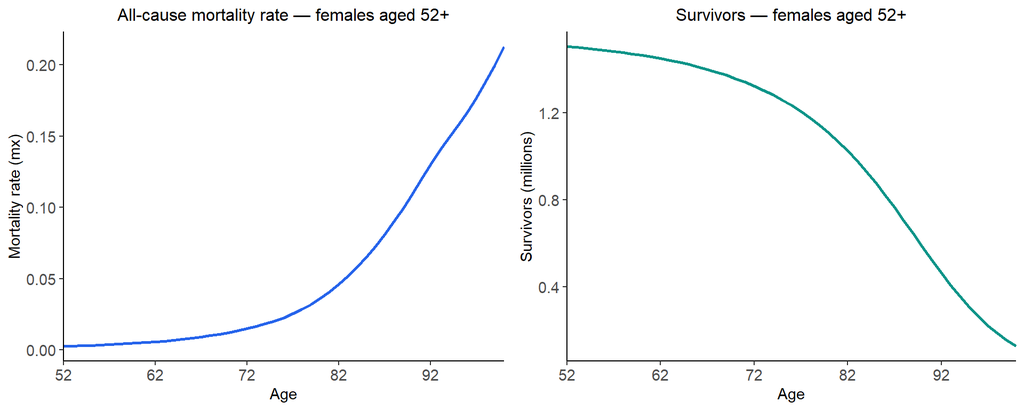

Reference life table for females aged 52+. Left: all-cause mortality rate rising with age. Right: cohort survivors declining over time.

```r
p1 <- ggplot(lt_ref, aes(x = age, y = mx)) +
  geom_line(colour = "#2563EB", linewidth = 1) +
  scale_x_continuous(limits = c(52, 100), breaks = seq(52, 100, 10),
                     expand = c(0, 0)) +
  labs(title = "All-cause mortality rate — females aged 52+",
       x = "Age", y = "Mortality rate (mx)") +
  theme_classic() +
  theme(plot.title = element_text(size = 12, hjust = 0.5),
        axis.text  = element_text(size = 11),
        axis.title = element_text(size = 11))

p2 <- ggplot(lt_ref, aes(x = age, y = lx / 1e6)) +
  geom_line(colour = "#0D9488", linewidth = 1) +
  scale_x_continuous(limits = c(52, 100), breaks = seq(52, 100, 10),
                     expand = c(0, 0)) +
  labs(title = "Survivors — females aged 52+",
       x = "Age", y = "Survivors (millions)") +
  theme_classic() +
  theme(plot.title = element_text(size = 12, hjust = 0.5),
        axis.text  = element_text(size = 11),
        axis.title = element_text(size = 11))

gridExtra::grid.arrange(p1, p2, ncol = 2)
```

## 2.2 What if mortality improves over time?

The reference life table above uses **static** mortality rates — the same `mx` at every age, regardless of which calendar year the cohort reaches that age. This is a simplification. In reality, mortality rates change over time as healthcare, living standards, and disease management improve (or worsen).

### 2.2.1 How the trend is modelled

The `mx_trend` argument applies an **annual percentage change** that **compounds** across simulation years. Because each row of the life table represents the cohort one year older — and therefore one calendar year further into the future — the multiplier accumulates:

$$m_x^{\text{projected}} = m_x \times \left(1 - \frac{\text{trend}}{100}\right)^{t-1}$$

where $t = 1$ at cohort entry (no change), $t = 2$ one year later, and so on.

**Why compound, not linear?**

A linear reduction of 0.5% per year would eventually drive `mx` negative, which is impossible. Compounding means each year’s rate is 0.5% lower than the *already-improved* previous year — both mathematically correct and epidemiologically realistic.

The table below shows how a 0.5% annual reduction accumulates for a starting `mx = 0.01`:

| Simulation year | Age | Multiplier | Projected mx |
| --- | --- | --- | --- |
| 1 | 52 | $(0.995)^0 = 1.0000$ | 0.01000 |
| 2 | 53 | $(0.995)^1 = 0.9950$ | 0.00995 |
| 5 | 56 | $(0.995)^4 = 0.9802$ | 0.00980 |
| 10 | 61 | $(0.995)^9 = 0.9559$ | 0.00956 |
| 20 | 71 | $(0.995)^{19} = 0.9085$ | 0.00909 |
| 30 | 81 | $(0.995)^{29} = 0.8636$ | 0.00864 |
| 49 | 100 | $(0.995)^{48} = 0.7851$ | 0.00785 |

By the terminal age the mortality rate is ~21% lower than at entry, reflecting nearly 50 years of accumulated improvement.

### 2.2.2 Running the life table with a 0.5% annual trend

```r
lt_trend <- RunLifeTable(
  in_data    = mslt_general,
  in_sex     = "female",
  in_mid_age = 52,
  mx_trend   = 0.5,   # 0.5% annual reduction in mx, compounding each year
  scenario   = 0
) %>%
  mutate(label = "With trend (−0.5%/yr)")

write_csv(lt_trend, "outputs/lecture_5_6/life_table_trend.csv")
```

### 2.2.3 Comparing reference vs trend

```r
gain_ly_trend  <- sum(lt_trend$Lx)  - sum(lt_ref$Lx)
gain_hly_trend <- sum(lt_trend$Lwx) - sum(lt_ref$Lwx)
gain_ex_trend  <- (lt_trend$ex[1]   - lt_ref$ex[1]) * 365

cat(sprintf("Difference in person-years lived (Lx):           %s\n",
            format(round(gain_ly_trend),  big.mark = ",")))
```

```
Difference in person-years lived (Lx):           1,626,663
```

```r
cat(sprintf("Difference in health-adjusted life years (Lwx):  %s\n",
            format(round(gain_hly_trend), big.mark = ",")))
```

```
Difference in health-adjusted life years (Lwx):  1,102,155
```

```r
cat(sprintf("Difference in life expectancy:                   %.1f days (%.2f years)\n",
            gain_ex_trend, gain_ex_trend / 365))
```

```
Difference in life expectancy:                   394.3 days (1.08 years)
```

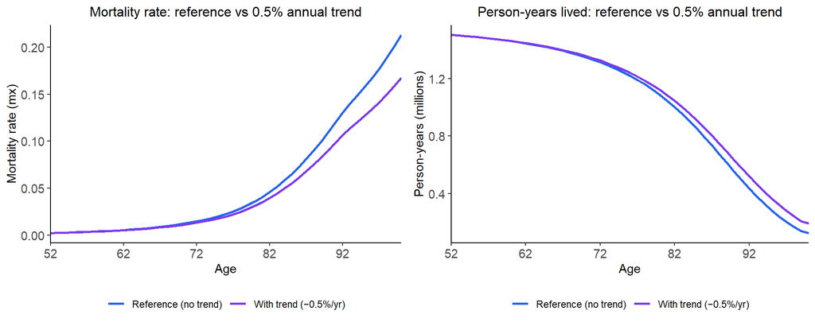

```r
lt_compare_trend <- bind_rows(lt_ref, lt_trend)

p_mx <- ggplot(lt_compare_trend, aes(x = age, y = mx, colour = label)) +
  geom_line(linewidth = 1) +
  scale_colour_manual(values = c("Reference (no trend)"    = "#2563EB",
                                 "With trend (−0.5%/yr)"   = "#7C3AED")) +
  scale_x_continuous(limits = c(52, 100), breaks = seq(52, 100, 10),
                     expand = c(0, 0)) +
  labs(title = "Mortality rate: reference vs 0.5% annual trend",
       x = "Age", y = "Mortality rate (mx)", colour = NULL) +
  theme_classic() +
  theme(plot.title = element_text(size = 12, hjust = 0.5),
        axis.text  = element_text(size = 11),
        axis.title = element_text(size = 11),
        legend.position = "bottom")

p_lx <- ggplot(lt_compare_trend, aes(x = age, y = Lx / 1e6, colour = label)) +
  geom_line(linewidth = 1) +
  scale_colour_manual(values = c("Reference (no trend)"    = "#2563EB",
                                 "With trend (−0.5%/yr)"   = "#7C3AED")) +
  scale_x_continuous(limits = c(52, 100), breaks = seq(52, 100, 10),
                     expand = c(0, 0)) +
  labs(title = "Person-years lived: reference vs 0.5% annual trend",
       x = "Age", y = "Person-years (millions)", colour = NULL) +
  theme_classic() +
  theme(plot.title = element_text(size = 12, hjust = 0.5),
        axis.text  = element_text(size = 11),
        axis.title = element_text(size = 11),
        legend.position = "bottom")

gridExtra::grid.arrange(p_mx, p_lx, ncol = 2)
```

| Scenario | Life expectancy | HA life expectancy | Sum Lx | Sum Lwx |
| --- | --- | --- | --- | --- |
| Reference (no trend) | 33.61 | 26.04 | 50,614,908 | 39,206,516 |
| With trend (−0.5%/yr) | 34.69 | 26.77 | 52,241,571 | 40,308,671 |
| Difference | 1.08 | 0.73 | 1,626,663 | 1,102,155 |

**Interpretation**

A 0.5% annual compound reduction in all-cause mortality adds approximately 1,626,663 person-years to this cohort over their remaining lifetime and increases life expectancy by about 394 days. The effect is larger than it may seem because compounding means the improvement accumulates silently over decades.

**Extending this**

`mx_trend` can also be **negative** to model worsening mortality (e.g. `mx_trend = -1` for a 1% annual increase). Any value can be stacked on top of a PIF-based `scenario` reduction — the two mechanisms are applied independently and in sequence.

# 3 Scenario 1 — Direct Mortality Reduction (5%)

**Question:** What is the gain in life years and life expectancy if all-cause mortality is reduced by 5% across all ages?

The `scenario` argument applies a one-off proportional reduction to `mx` at every age:

$$m_x^{\text{scenario}} = m_x \times (1 - \text{scenario})$$

This is distinct from `mx_trend`, which compounds year-on-year. The two can be combined: `scenario` captures a structural shift (e.g. from a policy intervention) while `mx_trend` captures background secular change.

```r
lt_sc5 <- RunLifeTable(
  in_data    = mslt_general,
  in_sex     = "female",
  in_mid_age = 52,
  mx_trend   = NA,
  scenario   = 0.05      # 5% one-off reduction at all ages
) %>%
  mutate(label = "5% mortality reduction")

write_csv(lt_sc5, "outputs/lecture_5_6/life_table_scenario_5pct.csv")
```

## 3.1 Comparing reference vs scenario

```r
gain_ly  <- sum(lt_sc5$Lx)  - sum(lt_ref$Lx)
gain_hly <- sum(lt_sc5$Lwx) - sum(lt_ref$Lwx)
gain_ex  <- (lt_sc5$ex[1]   - lt_ref$ex[1]) * 365

cat(sprintf("Gain in person-years lived (Lx):           %s\n",
            format(round(gain_ly),  big.mark = ",")))
```

```
Gain in person-years lived (Lx):           660,595
```

```r
cat(sprintf("Gain in health-adjusted life years (Lwx):  %s\n",
            format(round(gain_hly), big.mark = ",")))
```

```
Gain in health-adjusted life years (Lwx):  461,265
```

```r
cat(sprintf("Gain in life expectancy:                   %.1f days (%.2f years)\n",
            gain_ex, gain_ex / 365))
```

```
Gain in life expectancy:                   160.1 days (0.44 years)
```

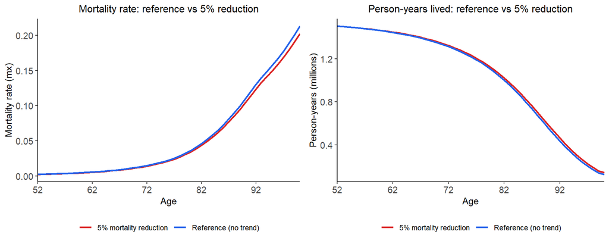

```r
lt_compare <- bind_rows(lt_ref, lt_sc5)

p3 <- ggplot(lt_compare, aes(x = age, y = mx, colour = label)) +
  geom_line(linewidth = 1) +
  scale_colour_manual(values = c("Reference (no trend)"   = "#2563EB",
                                 "5% mortality reduction" = "#DC2626")) +
  scale_x_continuous(limits = c(52, 100), breaks = seq(52, 100, 10),
                     expand = c(0, 0)) +
  labs(title = "Mortality rate: reference vs 5% reduction",
       x = "Age", y = "Mortality rate (mx)", colour = NULL) +
  theme_classic() +
  theme(plot.title = element_text(size = 12, hjust = 0.5),
        axis.text  = element_text(size = 11),
        axis.title = element_text(size = 11),
        legend.position = "bottom")

p4 <- ggplot(lt_compare, aes(x = age, y = Lx / 1e6, colour = label)) +
  geom_line(linewidth = 1) +
  scale_colour_manual(values = c("Reference (no trend)"   = "#2563EB",
                                 "5% mortality reduction" = "#DC2626")) +
  scale_x_continuous(limits = c(52, 100), breaks = seq(52, 100, 10),
                     expand = c(0, 0)) +
  labs(title = "Person-years lived: reference vs 5% reduction",
       x = "Age", y = "Person-years (millions)", colour = NULL) +
  theme_classic() +
  theme(plot.title = element_text(size = 12, hjust = 0.5),
        axis.text  = element_text(size = 11),
        axis.title = element_text(size = 11),
        legend.position = "bottom")

gridExtra::grid.arrange(p3, p4, ncol = 2)
```

## 3.2 Summary table — reference, trend, and scenario

| Scenario | Life expectancy | HA life expectancy | Sum Lx |
| --- | --- | --- | --- |
| Reference (no trend) | 33.61 | 26.04 | 50,614,908 |
| With trend (−0.5%/yr) | 34.69 | 26.77 | 52,241,571 |
| 5% mortality reduction | 34.05 | 26.34 | 51,275,504 |
| Difference (trend vs ref) | 1.08 | 0.73 | 1,626,663 |
| Difference (5% sc vs ref) | 0.44 | 0.31 | 660,595 |

**Scenario vs trend — a key teaching point**

# 4 Scenario 2 — Physical Activity Increase (Bogotá)

**Question:** What is the gain in life years from a population-level increase in physical activity (+2 mMET-hours/week) for the Bogotá population?

The pathway is:

$$\text{PA distribution} \xrightarrow{\text{dose-response}} \text{RR by individual} \xrightarrow{\text{PIF}} \Delta m_x \xrightarrow{\text{life table}} \Delta \text{life years}$$

## 4.1 Step 1 — Assign individual-level RRs

```r
diseases <- "all-cause-mortality"

bogota_ref  <- assignPA_RRs(bogota_mmets, diseases = diseases,
                             mmet_col = "mmet_ref")
bogota_scen <- assignPA_RRs(bogota_mmets, diseases = diseases,
                             mmet_col = "mmet_scen")

# Sanity check — RR should be <= 1
cat("Reference RR summary:\n")
```

```
Reference RR summary:
```

```r
summary(bogota_ref$`rr_PHYSICAL_ACTIVITY_all-cause-mortality`)
```

```
   Min. 1st Qu.  Median    Mean 3rd Qu.    Max.
 0.6755  0.6755  0.6875  0.7435  0.7768  1.0000
```

```r
cat("\nScenario RR summary (should be slightly lower):\n")
```

```
Scenario RR summary (should be slightly lower):
```

```r
summary(bogota_scen$`rr_PHYSICAL_ACTIVITY_all-cause-mortality`)
```

```
   Min. 1st Qu.  Median    Mean 3rd Qu.    Max.
 0.6755  0.6755  0.6787  0.7236  0.7263  1.0000
```

## 4.2 Step 2 — Calculate PIFs

$$\text{PIF} = \frac{\sum \text{RR}(\text{ref}) - \sum \text{RR}(\text{scen})}{\sum \text{RR}(\text{ref})}$$

```r
pif_results <- calculate_pif(pop_ref = bogota_ref, pop_scen = bogota_scen)
pifs        <- pif_results$pif_table

print(pifs, n = Inf)
```

```
# A tibble: 22 × 7
   sex    age_cat cause                   n sum_rr_ref sum_rr_scen  pif_pa
   <chr>  <chr>   <chr>               <int>      <dbl>       <dbl>   <dbl>
 1 female 15-19   all_cause_mortality  6650      6066.       6026. 0.00668
 2 female 20-24   all_cause_mortality  5235      3761.       3650. 0.0295
 3 female 25-29   all_cause_mortality  5185      3725.       3615. 0.0295
 4 female 30-34   all_cause_mortality  5312      3820.       3706. 0.0299
 5 female 35-39   all_cause_mortality  5298      3800.       3691. 0.0288
 6 female 40-44   all_cause_mortality  5135      3688.       3580. 0.0294
 7 female 45-49   all_cause_mortality  5322      3824.       3711. 0.0296
 8 female 50-54   all_cause_mortality  4687      3369.       3269. 0.0297
 9 female 55-59   all_cause_mortality  4823      3458.       3359. 0.0287
10 female 60-64   all_cause_mortality  3903      2805.       2722. 0.0298
11 female 65-69   all_cause_mortality  4043      2905.       2819. 0.0296
12 male   15-19   all_cause_mortality  6671      6095.       6047. 0.00784
13 male   20-24   all_cause_mortality  5268      3794.       3679. 0.0303
14 male   25-29   all_cause_mortality  5182      3736.       3621. 0.0309
15 male   30-34   all_cause_mortality  4880      3522.       3412. 0.0313
16 male   35-39   all_cause_mortality  4947      3574.       3461. 0.0316
17 male   40-44   all_cause_mortality  5088      3676.       3560. 0.0317
18 male   45-49   all_cause_mortality  5023      3620.       3509. 0.0306
19 male   50-54   all_cause_mortality  4338      3130.       3033. 0.0311
20 male   55-59   all_cause_mortality  4187      3025.       2929. 0.0316
21 male   60-64   all_cause_mortality  3599      2594.       2514. 0.0306
22 male   65-69   all_cause_mortality  3642      2622.       2543. 0.0302
```

## 4.3 Step 3 — Extract PIF for the 50–54 female cohort (NEEDS fixing, PIFS are age specific)

```r
pif_female_5054 <- pifs %>%
  filter(sex == "female", age_cat == "50-54") %>%
  pull(pif_pa)

cat(sprintf("PIF for all-cause mortality (female, 50–54): %.4f (%.2f%%)\n",
            pif_female_5054, pif_female_5054 * 100))
```

```
PIF for all-cause mortality (female, 50–54): 0.0297 (2.97%)
```

## 4.4 Step 4 — Run life table with PIF-modified mortality

$$m_x^{\text{PA scenario}} = m_x \times (1 - \text{PIF})$$

```r
lt_pa <- RunLifeTable(
  in_data    = mslt_general,
  in_sex     = "female",
  in_mid_age = 52,
  mx_trend   = NA,
  scenario   = pif_female_5054
) %>%
  mutate(label = "PA scenario (+2 mMETs)")

write_csv(lt_pa, "outputs/lecture_5_6/life_table_pa_scenario.csv")
```

## 4.5 Step 5 — Compare reference vs PA scenario

```r
gain_ly_pa  <- sum(lt_pa$Lx)  - sum(lt_ref$Lx)
gain_hly_pa <- sum(lt_pa$Lwx) - sum(lt_ref$Lwx)
gain_ex_pa  <- (lt_pa$ex[1]   - lt_ref$ex[1]) * 365

cat(sprintf("Gain in person-years lived (Lx):          %s\n",
            format(round(gain_ly_pa),  big.mark = ",")))
```

```
Gain in person-years lived (Lx):          388,325
```

```r
cat(sprintf("Gain in health-adjusted life years (Lwx): %s\n",
            format(round(gain_hly_pa), big.mark = ",")))
```

```
Gain in health-adjusted life years (Lwx): 271,299
```

```r
cat(sprintf("Gain in life expectancy:                  %.1f days\n",
            gain_ex_pa))
```

```
Gain in life expectancy:                  94.1 days
```

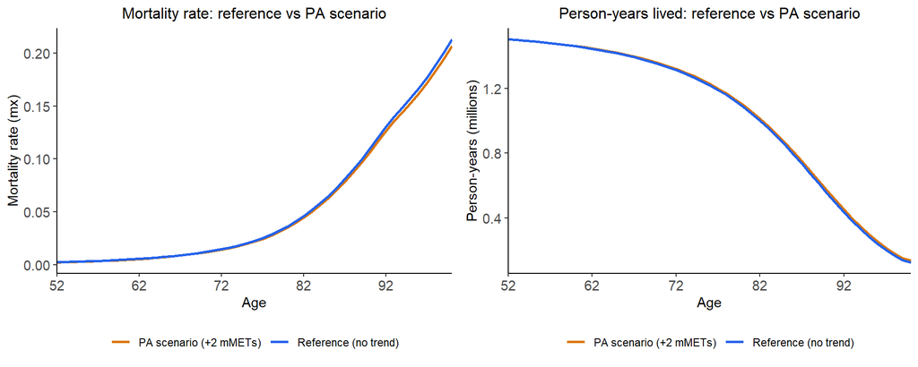

PA scenario vs reference. The PIF reduces mx proportionally at all ages, similar in shape to the 5% one-off reduction but typically smaller in magnitude.

```r
lt_compare_pa <- bind_rows(lt_ref, lt_pa)

p5 <- ggplot(lt_compare_pa, aes(x = age, y = mx, colour = label)) +
  geom_line(linewidth = 1) +
  scale_colour_manual(values = c("Reference (no trend)"    = "#2563EB",
                                 "PA scenario (+2 mMETs)"  = "#D97706")) +
  scale_x_continuous(limits = c(52, 100), breaks = seq(52, 100, 10),
                     expand = c(0, 0)) +
  labs(title = "Mortality rate: reference vs PA scenario",
       x = "Age", y = "Mortality rate (mx)", colour = NULL) +
  theme_classic() +
  theme(plot.title = element_text(size = 12, hjust = 0.5),
        axis.text  = element_text(size = 11),
        axis.title = element_text(size = 11),
        legend.position = "bottom")

p6 <- ggplot(lt_compare_pa, aes(x = age, y = Lx / 1e6, colour = label)) +
  geom_line(linewidth = 1) +
  scale_colour_manual(values = c("Reference (no trend)"    = "#2563EB",
                                 "PA scenario (+2 mMETs)"  = "#D97706")) +
  scale_x_continuous(limits = c(52, 100), breaks = seq(52, 100, 10),
                     expand = c(0, 0)) +
  labs(title = "Person-years lived: reference vs PA scenario",
       x = "Age", y = "Person-years (millions)", colour = NULL) +
  theme_classic() +
  theme(plot.title = element_text(size = 12, hjust = 0.5),
        axis.text  = element_text(size = 11),
        axis.title = element_text(size = 11),
        legend.position = "bottom")

gridExtra::grid.arrange(p5, p6, ncol = 2)
```

## 4.6 Summary table — all scenarios

| Scenario | mx_trend | scenario (PIF) | Life expectancy | HA life expectancy | Gain Lx | Gain Lwx |
| --- | --- | --- | --- | --- | --- | --- |
| Reference (no trend) | NA | 0 | 33.61 | 26.04 | — | — |
| With trend (−0.5%/yr) | 0.5 | 0 | 34.69 | 26.77 | 1,626,663 | 1,102,155 |
| 5% mortality reduction | NA | 5% | 34.05 | 26.34 | 660,595 | 461,265 |
| PA scenario (+2 mMETs) | NA | 2.97% | 33.87 | 26.22 | 388,325 | 271,299 |

**Interpretation**

## 4.7 Exercise — extend to multiple cohorts

Try running the full pipeline for **males aged 52** and for **females aged 37**, both with and without the 0.5% trend. What happens to the absolute life-year gains? Why does the trend matter more for younger cohorts?

```r
for (sex_i in c("female", "male")) {
  for (age_i in c(37, 52, 62)) {

    age_cat_i <- bogota_mmets %>%
      filter(age == age_i) %>%
      pull(age_cat) %>%
      unique()

    pif_i <- pifs %>%
      filter(sex == sex_i, age_cat == age_cat_i) %>%
      pull(pif_pa)

    lt_ref_i <- RunLifeTable(mslt_general, sex_i, age_i,
                              mx_trend = NA, scenario = 0)
    lt_trend_i <- RunLifeTable(mslt_general, sex_i, age_i,
                                mx_trend = 0.5, scenario = 0)
    lt_pa_i   <- RunLifeTable(mslt_general, sex_i, age_i,
                               mx_trend = NA, scenario = pif_i)
    lt_both_i <- RunLifeTable(mslt_general, sex_i, age_i,
                               mx_trend = 0.5, scenario = pif_i)

    cat(sprintf(
      "%s aged %d | PIF: %.2f%% | Gain PA: %s | Gain trend: %s | Gain both: %s\n",
      sex_i, age_i,
      pif_i * 100,
      format(round(sum(lt_pa_i$Lx)   - sum(lt_ref_i$Lx)),  big.mark = ","),
      format(round(sum(lt_trend_i$Lx) - sum(lt_ref_i$Lx)), big.mark = ","),
      format(round(sum(lt_both_i$Lx)  - sum(lt_ref_i$Lx)), big.mark = ",")
    ))
  }
}
```

# 5 Disease Tables — Three-State Model

So far we have worked with a **two-state life table**: alive → dead, driven by all-cause mortality. The multi-state life table extends this by adding a **disease layer** for each condition of interest. Each disease follows the three-state process from Barendregt et al. (1998):

$$\text{Healthy} (S_x) \xrightarrow{\text{incidence}} \text{Diseased} (C_x) \xrightarrow{\text{case fatality}} \text{Dead from disease} (D_x)$$

with the constraint $S_x + C_x + D_x = 1{,}000$ at every age.

`RunDisease()` implements this process. It accepts the same `inc_trend` and `cf_trend` scalar parameters as `RunLifeTable()` accepts `mx_trend` — a compounding annual percentage change applied across simulation years:

$$\text{incidence}[t] = \text{incidence}[1] \times \left(1 - \frac{\text{inc\_trend}}{100}\right)^{t-1}$$

## 5.1 Disease table variables

| Variable | Meaning |
| --- | --- |
| `Sx` | Healthy people at age x (out of 1,000) |
| `Cx` | People with the disease at age x |
| `Dx` | Dead from disease at age x |
| `px` | Prevalence = Cx / (Sx + Cx) |
| `mx` | Disease-specific mortality rate |
| `incidence_disease` | Rate of new disease onset |
| `case_fatality_disease` | Rate of dying given diseased |
| `dw` | Disability weight for this disease |
| `PYx` | Person-years at risk |

## 5.2 Reference disease tables (no trends)

We run reference disease tables for all three Colombia diseases for the same cohort as the life table (females, age 52).

```r
# ── IHD reference ─────────────────────────────────────────────────────────────
dis_ref_ishd <- RunDisease(
  in_data      = mslt_general,
  in_sex       = "female",
  in_mid_age   = 52,
  in_disease   = "ishd",
  inc_trend    = NA,    # static rates
  cf_trend     = NA,
  scenario_inc = 0,
  scenario_cf  = 0
) %>% mutate(label = "Reference")

# ── COPD reference ────────────────────────────────────────────────────────────
dis_ref_copd <- RunDisease(
  in_data      = mslt_general,
  in_sex       = "female",
  in_mid_age   = 52,
  in_disease   = "copd",
  inc_trend    = NA,
  cf_trend     = NA,
  scenario_inc = 0,
  scenario_cf  = 0
) %>% mutate(label = "Reference")

# ── Type 2 diabetes reference ─────────────────────────────────────────────────
dis_ref_dmt2 <- RunDisease(
  in_data      = mslt_general,
  in_sex       = "female",
  in_mid_age   = 52,
  in_disease   = "dmt2",
  inc_trend    = NA,
  cf_trend     = NA,
  scenario_inc = 0,
  scenario_cf  = 0
) %>% mutate(label = "Reference")

# Inspect IHD first 8 rows
dis_ref_ishd %>%
  select(age, incidence_disease, case_fatality_disease, Sx, Cx, Dx, px, mx) %>%
  head(8)
```

```
  age incidence_disease case_fatality_disease        Sx        Cx          Dx
1  52       0.001221349            0.01596088 1000.0000  0.000000 0.000000000
2  53       0.001336175            0.01686154  998.7794  1.210912 0.009691299
3  54       0.001460733            0.01781674  997.4457  2.513135 0.041121232
4  55       0.001597109            0.01882732  995.9898  3.911798 0.098397078
5  56       0.001745024            0.01987983  994.4004  5.413399 0.186229657
6  57       0.001905175            0.02097747  992.6666  7.023459 0.309909010
7  58       0.002076836            0.02210642  990.7772  8.747377 0.475394668
8  59       0.002260479            0.02326163  988.7217 10.589111 0.689207823
           px           mx
1 0.000000000 0.000000e+00
2 0.001210924 2.024717e-05
3 0.002513238 4.438246e-05
4 0.003912183 7.297008e-05
5 0.005414408 1.065812e-04
6 0.007025636 1.458571e-04
7 0.008751537 1.913629e-04
8 0.010596414 2.436779e-04
```

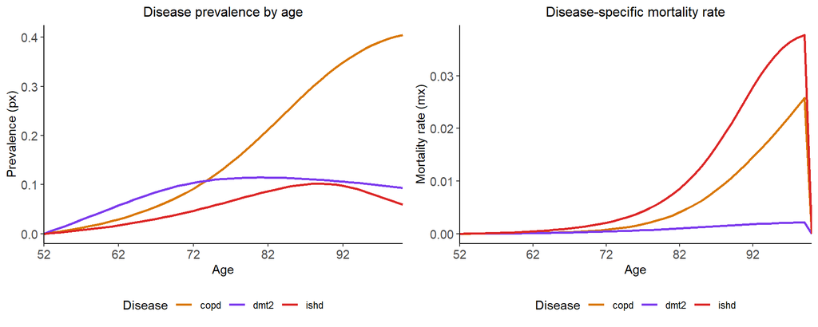

Disease prevalence (left) and disease-specific mortality rate (right) for IHD, COPD and type 2 diabetes — females aged 52+, Colombia, reference (no trends).

```r
dis_all_ref <- bind_rows(dis_ref_ishd, dis_ref_copd, dis_ref_dmt2)

pp1 <- ggplot(dis_all_ref, aes(x = age, y = px, colour = disease)) +
  geom_line(linewidth = 1) +
  scale_x_continuous(limits = c(52, 100), breaks = seq(52, 100, 10), expand = c(0, 0)) +
  scale_colour_manual(values = c("ishd" = "#DC2626", "copd" = "#D97706", "dmt2" = "#7C3AED")) +
  labs(title = "Disease prevalence by age", x = "Age", y = "Prevalence (px)", colour = "Disease") +
  theme_classic() +
  theme(plot.title = element_text(size = 12, hjust = 0.5),
        axis.text = element_text(size = 11), axis.title = element_text(size = 11),
        legend.position = "bottom")

pp2 <- ggplot(dis_all_ref, aes(x = age, y = mx, colour = disease)) +
  geom_line(linewidth = 1) +
  scale_x_continuous(limits = c(52, 100), breaks = seq(52, 100, 10), expand = c(0, 0)) +
  scale_colour_manual(values = c("ishd" = "#DC2626", "copd" = "#D97706", "dmt2" = "#7C3AED")) +
  labs(title = "Disease-specific mortality rate", x = "Age", y = "Mortality rate (mx)", colour = "Disease") +
  theme_classic() +
  theme(plot.title = element_text(size = 12, hjust = 0.5),
        axis.text = element_text(size = 11), axis.title = element_text(size = 11),
        legend.position = "bottom")

gridExtra::grid.arrange(pp1, pp2, ncol = 2)
```

## 5.3 Adding an incidence trend

Exactly as `mx_trend` in `RunLifeTable()`, `inc_trend = 0.5` applies a 0.5% annual compounding reduction in incidence across simulation years. The formula is:

$$\text{incidence}[t] = \text{incidence}[1] \times (0.995)^{t-1}$$

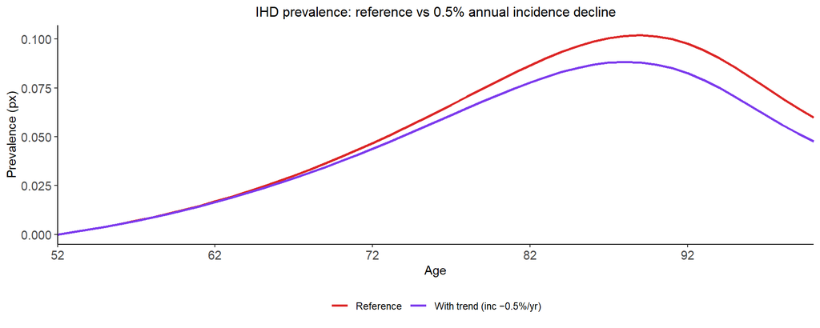

```r
dis_trend_ishd <- RunDisease(
  in_data      = mslt_general,
  in_sex       = "female",
  in_mid_age   = 52,
  in_disease   = "ishd",
  inc_trend    = 0.5,   # 0.5% annual decline in incidence, compounding
  cf_trend     = NA,
  scenario_inc = 0,
  scenario_cf  = 0
) %>% mutate(label = "With trend (inc −0.5%/yr)")

# Compare IHD prevalence reference vs trend
dis_ishd_compare <- bind_rows(dis_ref_ishd, dis_trend_ishd)

ggplot(dis_ishd_compare, aes(x = age, y = px, colour = label)) +
  geom_line(linewidth = 1) +
  scale_colour_manual(values = c("Reference" = "#DC2626",
                                 "With trend (inc −0.5%/yr)" = "#7C3AED")) +
  scale_x_continuous(limits = c(52, 100), breaks = seq(52, 100, 10), expand = c(0, 0)) +
  labs(title = "IHD prevalence: reference vs 0.5% annual incidence decline",
       x = "Age", y = "Prevalence (px)", colour = NULL) +
  theme_classic() +
  theme(plot.title = element_text(size = 12, hjust = 0.5),
        axis.text = element_text(size = 11), axis.title = element_text(size = 11),
        legend.position = "bottom")
```

## 5.4 Disease Scenario 1 — 5% reduction in incidence

**Question:** What happens to disease prevalence and disease-specific mortality if incidence falls by 5% permanently at all ages?

```r
# Run 5% scenario for all three diseases
dis_sc5_ishd <- RunDisease(
  in_data      = mslt_general,
  in_sex       = "female",
  in_mid_age   = 52,
  in_disease   = "ishd",
  inc_trend    = NA,
  cf_trend     = NA,
  scenario_inc = 0.05,    # 5% one-off reduction in incidence
  scenario_cf  = 0
) %>% mutate(label = "5% incidence reduction")

dis_sc5_copd <- RunDisease(
  in_data      = mslt_general,
  in_sex       = "female",
  in_mid_age   = 52,
  in_disease   = "copd",
  inc_trend    = NA,
  cf_trend     = NA,
  scenario_inc = 0.05,
  scenario_cf  = 0
) %>% mutate(label = "5% incidence reduction")

dis_sc5_dmt2 <- RunDisease(
  in_data      = mslt_general,
  in_sex       = "female",
  in_mid_age   = 52,
  in_disease   = "dmt2",
  inc_trend    = NA,
  cf_trend     = NA,
  scenario_inc = 0.05,
  scenario_cf  = 0
) %>% mutate(label = "5% incidence reduction")
```

```r
# Compare reference vs 5% scenario for each disease
for (dis_name in c("ishd", "copd", "dmt2")) {
  ref <- get(paste0("dis_ref_", dis_name))
  sc5 <- get(paste0("dis_sc5_", dis_name))

  cat(sprintf("\n── %s ──────────────────────────────\n", toupper(dis_name)))
  cat(sprintf("  Cases prevented (sum Cx diff):           %s\n",
              format(round(sum(sc5$Cx) - sum(ref$Cx)), big.mark = ",")))
  cat(sprintf("  Disease deaths prevented (sum Dx diff):  %s\n",
              format(round(sum(sc5$Dx) - sum(ref$Dx)), big.mark = ",")))
  cat(sprintf("  Mean prevalence change:                  %.4f → %.4f\n",
              mean(ref$px), mean(sc5$px)))
}
```

```
── ISHD ──────────────────────────────
  Cases prevented (sum Cx diff):           -101
  Disease deaths prevented (sum Dx diff):  -183
  Mean prevalence change:                  0.0550 → 0.0522

── COPD ──────────────────────────────
  Cases prevented (sum Cx diff):           -300
  Disease deaths prevented (sum Dx diff):  -85
  Mean prevalence change:                  0.1685 → 0.1612

── DMT2 ──────────────────────────────
  Cases prevented (sum Cx diff):           -196
  Disease deaths prevented (sum Dx diff):  -23
  Mean prevalence change:                  0.0855 → 0.0814
```

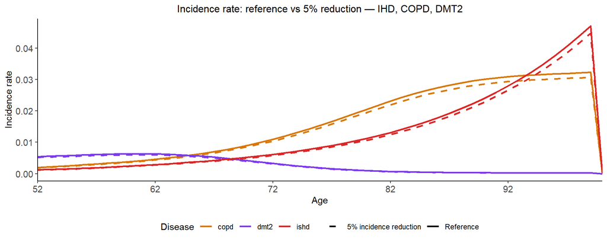

```r
dis_all_sc5 <- bind_rows(
  dis_ref_ishd, dis_sc5_ishd,
  dis_ref_copd, dis_sc5_copd,
  dis_ref_dmt2, dis_sc5_dmt2
)

ggplot(dis_all_sc5, aes(x = age, y = incidence_disease, colour = disease, linetype = label)) +
  geom_line(linewidth = 1) +
  scale_x_continuous(limits = c(52, 100), breaks = seq(52, 100, 10), expand = c(0, 0)) +
  scale_colour_manual(values = c("ishd" = "#DC2626", "copd" = "#D97706", "dmt2" = "#7C3AED")) +
  scale_linetype_manual(values = c("Reference" = "solid", "5% incidence reduction" = "dashed")) +
  labs(title = "Incidence rate: reference vs 5% reduction — IHD, COPD, DMT2",
       x = "Age", y = "Incidence rate", colour = "Disease", linetype = NULL) +
  theme_classic() +
  theme(plot.title = element_text(size = 12, hjust = 0.5),
        axis.text = element_text(size = 11), axis.title = element_text(size = 11),
        legend.position = "bottom")
```

**Key teaching point — disease scenario vs life table scenario**

`scenario_inc = 0.05` in `RunDisease()` reduces incidence by 5% at every age. The full effect on life years only materialises inside `CalculationModel()`, which propagates the disease mortality reduction into the general life table. The disease table alone shows you the epidemiological change; the MSLT shows you the life-years consequence.

# 6 Complete MSLT — Physical Activity and Diseases

The full proportional multi-state life table (Barendregt et al. 1998) combines:

1. A **general life table** tracking total survival (from `RunLifeTable()`)
2. **Disease sections** for each modelled condition (from `RunDisease()`)
3. **Feedback**: disease-specific mortality from step 2 modifies total `mx` in step 1

`CalculationModel()` runs all three components simultaneously and returns differences (scenario − reference) in life years, health-adjusted life years, and disease-specific incidence and mortality.

## 6.1 Disease 2 — PA scenario with disease-specific PIFs

**Question:** What is the gain in life years and health-adjusted life years from a +2 mMET PA increase, modelled through disease-specific incidence reductions for IHD, COPD and type 2 diabetes?

The pathway is:

$$\text{PA distribution} \xrightarrow{\text{dose-response}} \text{RR by disease} \xrightarrow{\text{PIF per disease}} \Delta\text{incidence} \xrightarrow{\text{MSLT}} \Delta\text{life years}$$

### 6.1.1 Step 1 — Assign disease-specific RRs

```r
# Disease names as used by the drpa package
diseases_mslt <- c(
  "coronary-heart-disease",
  # "chronic-obstructive-pulmonary-disease", not a physical activity disease
  "diabetes",
  "all-cause-mortality"          # also included for the life table component
)

# Assign RRs for reference and counterfactual PA distributions
bogota_ref  <- assignPA_RRs(bogota_mmets,
                                  diseases = diseases_mslt,
                                  mmet_col = "mmet_ref")
bogota_scen <- assignPA_RRs(bogota_mmets,
                                  diseases = diseases_mslt,
                                  mmet_col = "mmet_scen")

# Quick sanity check — all RRs should be <= 1 (PA is protective)
rr_cols <- grep("^rr_", names(bogota_ref), value = TRUE)
cat("Reference RR ranges:\n")
```

```
Reference RR ranges:
```

```r
for (col in rr_cols) {
  cat(sprintf("  %-60s min=%.4f  mean=%.4f\n",
              col, min(bogota_ref[[col]]), mean(bogota_ref[[col]])))
}
```

```
  rr_PHYSICAL_ACTIVITY_coronary-heart-disease                  min=0.7441  mean=0.8151
  rr_PHYSICAL_ACTIVITY_diabetes                                min=0.6387  mean=0.7600
  rr_PHYSICAL_ACTIVITY_all-cause-mortality                     min=0.6755  mean=0.7435
```

```r
cat("Scenario RR ranges:\n")
```

```
Scenario RR ranges:
```

```r
for (col in rr_cols) {
  cat(sprintf("  %-60s min=%.4f  mean=%.4f\n",
              col, min(bogota_scen[[col]]), mean(bogota_scen[[col]])))
}
```

```
  rr_PHYSICAL_ACTIVITY_coronary-heart-disease                  min=0.7441  mean=0.7975
  rr_PHYSICAL_ACTIVITY_diabetes                                min=0.6387  mean=0.7348
  rr_PHYSICAL_ACTIVITY_all-cause-mortality                     min=0.6755  mean=0.7236
```

### 6.1.2 Step 2 — Calculate disease-specific PIFs

```r
pif_results_mslt <- calculate_pif(pop_ref  = bogota_ref,
                                   pop_scen = bogota_scen)
pifs_mslt        <- pif_results_mslt$pif_table %>% rename(disease = cause)

cat("PIFs by disease, sex and age group:\n")
```

```
PIFs by disease, sex and age group:
```

```r
print(pifs_mslt  %>% arrange(disease, sex, age_cat), n = Inf)
```

```
# A tibble: 66 × 7
   sex    age_cat disease                    n sum_rr_ref sum_rr_scen  pif_pa
   <chr>  <chr>   <chr>                  <int>      <dbl>       <dbl>   <dbl>
 1 female 15-19   all_cause_mortality     6650      6066.       6026. 0.00668
 2 female 20-24   all_cause_mortality     5235      3761.       3650. 0.0295
 3 female 25-29   all_cause_mortality     5185      3725.       3615. 0.0295
 4 female 30-34   all_cause_mortality     5312      3820.       3706. 0.0299
 5 female 35-39   all_cause_mortality     5298      3800.       3691. 0.0288
 6 female 40-44   all_cause_mortality     5135      3688.       3580. 0.0294
 7 female 45-49   all_cause_mortality     5322      3824.       3711. 0.0296
 8 female 50-54   all_cause_mortality     4687      3369.       3269. 0.0297
 9 female 55-59   all_cause_mortality     4823      3458.       3359. 0.0287
10 female 60-64   all_cause_mortality     3903      2805.       2722. 0.0298
11 female 65-69   all_cause_mortality     4043      2905.       2819. 0.0296
12 male   15-19   all_cause_mortality     6671      6095.       6047. 0.00784
```

[output cut: 54 more lines]

### 6.1.3 Step 3 — Extract PIFs for the female 50–54 cohort

```r
# Helper: pull one PIF value for the working cohort
get_pif <- function(disease_name, sex_val = "female", age_val = "50-54") {
  pifs_mslt %>%
    filter(disease == disease_name, sex == sex_val, age_cat == age_val) %>%
    pull(pif_pa)
}

pif_ishd <- get_pif("coronary_heart_disease")
pif_dmt2 <- get_pif("diabetes")
pif_acm  <- get_pif("all_cause_mortality")   # for the life table component

cat(sprintf("PIFs for females aged 50-54:\n"))
```

```
PIFs for females aged 50-54:
```

```r
cat(sprintf("  IHD:               %.4f (%.2f%%)\n", pif_ishd, pif_ishd * 100))
```

```
  IHD:               0.0238 (2.38%)
```

```r
cat(sprintf("  Type 2 diabetes:   %.4f (%.2f%%)\n", pif_dmt2, pif_dmt2 * 100))
```

```
  Type 2 diabetes:   0.0371 (3.71%)
```

```r
cat(sprintf("  All-cause (LT):    %.4f (%.2f%%)\n", pif_acm,  pif_acm  * 100))
```

```
  All-cause (LT):    0.0297 (2.97%)
```

### 6.1.4 Step 4 — Run the complete MSLT

```r
# ── Validation: run with zero scenario — all differences must be zero ─────────
output_test <- CalculationModel(
  in_data      = mslt_general,
  in_sex       = "female",
  in_mid_age   = 52,
  mx_trend     = NA,
  in_disease   = c("ishd", "copd", "dmt2"),
  inc_trend    = NA,
  cf_trend     = NA,
  scenario_inc = 0,
  scenario_cf  = 0
)

cat("Validation checks (all must be zero):\n")
```

```
Validation checks (all must be zero):
```

```r
cat(sprintf("  sum(Lx_diff):              %.6f\n", sum(output_test$Lx_diff)))
```

```
  sum(Lx_diff):              0.000000
```

```r
cat(sprintf("  sum(Lwx_diff):             %.6f\n", sum(output_test$Lwx_diff)))
```

```
  sum(Lwx_diff):             0.000000
```

```r
cat(sprintf("  sum(inc_num_diff_ishd):    %.6f\n", sum(output_test$inc_num_diff_ishd)))
```

```
  sum(inc_num_diff_ishd):    0.000000
```

```r
cat(sprintf("  sum(inc_num_diff_copd):    %.6f\n", sum(output_test$inc_num_diff_copd)))
```

```
  sum(inc_num_diff_copd):    0.000000
```

```r
cat(sprintf("  sum(inc_num_diff_dmt2):    %.6f\n", sum(output_test$inc_num_diff_dmt2)))
```

```
  sum(inc_num_diff_dmt2):    0.000000
```

```r
# ── Scenario A: disease-specific PIFs — disease mortality feeds into general LT
# mx is modified through the disease pathway: incidence ↓ → prevalence ↓ →
# disease-specific mortality ↓ → total mx ↓
output_mslt_dis <- CalculationModel(
  in_data        = mslt_general,
  in_sex         = "female",
  in_mid_age     = 52,
  mx_trend       = NA,
  in_disease     = c("ishd", "copd", "dmt2"),
  inc_trend      = NA,
  cf_trend       = NA,
  scenario       = 0,
  scenario_inc   = c(ishd = pif_ishd, copd = 0, dmt2 = pif_dmt2),
  scenario_cf    = 0,
  use_disease_mx = TRUE   # disease mortality changes propagate to general LT
)

write_csv(output_mslt_dis, "outputs/lecture_5_6/mslt_pa_disease_pifs.csv")

# ── Scenario B: same disease incidence changes, but mx modified via all-cause
# PIF directly — disease mortality feedback switched off.
# Disease incidence still changes (same scenario_inc as above) so case counts
# are produced, but the life-year effect enters via the all-cause PIF on mx
# rather than through the disease-mortality pathway.
output_mslt_acm <- CalculationModel(
  in_data        = mslt_general,
  in_sex         = "female",
  in_mid_age     = 52,
  mx_trend       = NA,
  in_disease     = c("ishd", "copd", "dmt2"),
  inc_trend      = NA,
  cf_trend       = NA,
  scenario       = pif_acm,   # all-cause PIF modifies mx directly
  scenario_inc   = c(ishd = pif_ishd, copd = 0, dmt2 = pif_dmt2),
  scenario_cf    = 0,
  use_disease_mx = FALSE  # disease mortality does NOT feed into general LT
)

write_csv(output_mslt_acm, "outputs/lecture_5_6/mslt_pa_allcause_pif.csv")
```

### 6.1.5 Step 5 — Results

```r
cat("── Scenario A: disease-specific PIFs → disease mortality in general LT ──\n")
```

```
── Scenario A: disease-specific PIFs → disease mortality in general LT ──
```

```r
cat(sprintf("  Total life years gained  (sum Lx_diff):  %s\n",
            format(round(sum(output_mslt_dis$Lx_diff)),  big.mark = ",")))
```

```
  Total life years gained  (sum Lx_diff):  55,914
```

```r
cat(sprintf("  Total HA life yrs gained (sum Lwx_diff): %s\n",
            format(round(sum(output_mslt_dis$Lwx_diff)), big.mark = ",")))
```

```
  Total HA life yrs gained (sum Lwx_diff): 38,408
```

```r
cat(sprintf("  Life expectancy gain (ex_diff at entry): %.1f days\n",
            output_mslt_dis$ex_diff[1] * 365))
```

```
  Life expectancy gain (ex_diff at entry): 13.6 days
```

```r
cat("\n── Disease cases and deaths prevented (Scenario A) ─────────────────────\n")
```

```
── Disease cases and deaths prevented (Scenario A) ─────────────────────
```

```r
cat(sprintf("  IHD cases prevented:   %s\n",
            format(round(abs(sum(output_mslt_dis$inc_num_diff_ishd))), big.mark = ",")))
```

```
  IHD cases prevented:   7,122
```

```r
cat(sprintf("  COPD cases prevented:  %s\n",
            format(round(abs(sum(output_mslt_dis$inc_num_diff_copd))), big.mark = ",")))
```

```
  COPD cases prevented:  990
```

```r
cat(sprintf("  DMT2 cases prevented:  %s\n",
            format(round(abs(sum(output_mslt_dis$inc_num_diff_dmt2))), big.mark = ",")))
```

```
  DMT2 cases prevented:  6,187
```

```r
cat(sprintf("  IHD deaths prevented:  %s\n",
            format(round(abs(sum(output_mslt_dis$mx_num_diff_ishd))),  big.mark = ",")))
```

```
  IHD deaths prevented:  4,889
```

```r
cat("\n── Scenario B: disease incidence changes + all-cause PIF on mx ──────────\n")
```

```
── Scenario B: disease incidence changes + all-cause PIF on mx ──────────
```

```r
cat(sprintf("  Total life years gained  (sum Lx_diff):  %s\n",
            format(round(sum(output_mslt_acm$Lx_diff)),  big.mark = ",")))
```

```
  Total life years gained  (sum Lx_diff):  388,325
```

```r
cat(sprintf("  Total HA life yrs gained (sum Lwx_diff): %s\n",
            format(round(sum(output_mslt_acm$Lwx_diff)), big.mark = ",")))
```

```
  Total HA life yrs gained (sum Lwx_diff): 271,299
```

```r
cat(sprintf("  Life expectancy gain (ex_diff at entry): %.1f days\n",
            output_mslt_acm$ex_diff[1] * 365))
```

```
  Life expectancy gain (ex_diff at entry): 94.1 days
```

```r
cat("  (Disease case counts are identical to Scenario A — same scenario_inc)\n")
```

```
  (Disease case counts are identical to Scenario A — same scenario_inc)
```

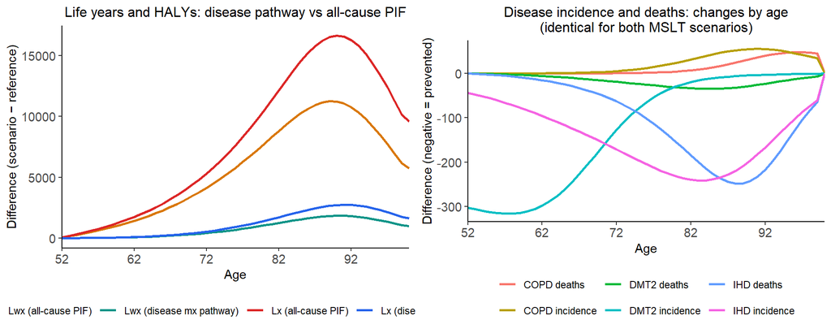

Left: life years and health-adjusted life years gained at each age — Scenario A (disease mortality pathway) vs Scenario B (all-cause PIF). Right: disease incidence and mortality changes (identical for both scenarios as they share the same scenario_inc).

```r
# ── Life years comparison: both MSLT scenarios ────────────────────────────────
ly_compare <- bind_rows(
  output_mslt_dis %>%
    transmute(age, sex,
              measure = "Lx (disease mx pathway)",    value = Lx_diff),
  output_mslt_dis %>%
    transmute(age, sex,
              measure = "Lwx (disease mx pathway)",   value = Lwx_diff),
  output_mslt_acm %>%
    transmute(age, sex,
              measure = "Lx (all-cause PIF)",         value = Lx_diff),
  output_mslt_acm %>%
    transmute(age, sex,
              measure = "Lwx (all-cause PIF)",        value = Lwx_diff)
)

p_ly <- ggplot(ly_compare, aes(x = age, y = value, colour = measure)) +
  geom_line(linewidth = 1) +
  scale_x_continuous(limits = c(52, 100), breaks = seq(52, 100, 10), expand = c(0, 0)) +
  scale_colour_manual(values = c(
    "Lx (disease mx pathway)"  = "#2563EB",
    "Lwx (disease mx pathway)" = "#0D9488",
    "Lx (all-cause PIF)"       = "#DC2626",
    "Lwx (all-cause PIF)"      = "#D97706"
  )) +
  labs(title = "Life years and HALYs: disease pathway vs all-cause PIF",
       x = "Age", y = "Difference (scenario − reference)", colour = NULL) +
  theme_classic() +
  theme(plot.title = element_text(size = 12, hjust = 0.5),
        axis.text = element_text(size = 11), axis.title = element_text(size = 11),
        legend.position = "bottom")

# ── Disease changes plot — same for both scenarios (shared scenario_inc) ───────
output_graphs <- output_mslt_dis %>%
  select(age, sex, inc_num_diff_ishd, inc_num_diff_copd, inc_num_diff_dmt2,
         mx_num_diff_ishd,  mx_num_diff_copd,  mx_num_diff_dmt2) %>%
  pivot_longer(cols = -c(age, sex), names_to = "measure") %>%
  mutate(measure = recode(measure,
    "inc_num_diff_ishd" = "IHD incidence",
    "inc_num_diff_copd" = "COPD incidence",
    "inc_num_diff_dmt2" = "DMT2 incidence",
    "mx_num_diff_ishd"  = "IHD deaths",
    "mx_num_diff_copd"  = "COPD deaths",
    "mx_num_diff_dmt2"  = "DMT2 deaths"))

p_dis <- ggplot(output_graphs, aes(x = age, y = value, colour = measure)) +
  geom_line(linewidth = 1) +
  scale_x_continuous(limits = c(52, 100), breaks = seq(52, 100, 10), expand = c(0, 0)) +
  labs(title = "Disease incidence and deaths: changes by age\n(identical for both MSLT scenarios)",
       x = "Age", y = "Difference (negative = prevented)", colour = NULL) +
  theme_classic() +
  theme(plot.title = element_text(size = 12, hjust = 0.5),
        axis.text = element_text(size = 11), axis.title = element_text(size = 11),
        legend.position = "bottom")

gridExtra::grid.arrange(p_ly, p_dis, ncol = 2)
```

## 6.2 Comparing all scenarios

[output not shown]

**Interpreting the three-way comparison**

**Approaches 2 and 3 use identical disease incidence changes** (`scenario_inc`) so their disease case counts are the same. The difference is entirely in how the mortality effect reaches the general life table:

- **Approach 2** (`use_disease_mx = TRUE`): the mortality reduction is mediated through disease — incidence falls, fewer people get IHD/DMT2, fewer die from those diseases, total mx falls. The life-year gain is bounded by how much IHD and DMT2 mortality contributes to all-cause mortality.
- **Approach 3** (`use_disease_mx = FALSE`): the same incidence changes happen (same case counts) but the general LT mx is reduced directly by the all-cause PIF. This is equivalent to saying: PA reduces mortality through all its pathways (not just the three modelled diseases), but we want to keep tracking disease cases separately.

If approach 2 and approach 3 give similar life-year totals, it suggests the disease-mortality pathway accounts for most of the all-cause PIF in this population. If approach 3 is substantially larger, there are important PA→mortality pathways beyond the three modelled diseases.

## 6.3 Exercise — extend to multiple cohorts and diseases

```r
# Run the full MSLT pipeline for males aged 52 and females aged 37
# Compare: how do disease-specific gains differ by sex and entry age?

for (sex_i in c("female", "male")) {
  for (age_i in c(37, 52)) {

    age_cat_i <- case_when(age_i == 37 ~ "35-39", age_i == 52 ~ "50-54")

    pif_ishd_i <- pifs_mslt %>%
      filter(disease == "coronary_heart_disease",
             sex == sex_i, age_cat == age_cat_i) %>%
      pull(pif_pa)
    pif_dmt2_i <- pifs_mslt %>%
      filter(disease == "diabetes",
             sex == sex_i, age_cat == age_cat_i) %>%
      pull(pif_pa)

    out_i <- CalculationModel(
      in_data      = mslt_general,
      in_sex       = sex_i,
      in_mid_age   = age_i,
      mx_trend     = NA,
      in_disease   = c("ishd", "copd", "dmt2"),
      inc_trend    = NA,
      cf_trend     = NA,
      scenario_inc = c(ishd = pif_ishd_i, copd = 0, dmt2 = pif_dmt2_i),
      scenario_cf  = 0
    )

    cat(sprintf(
      "%s aged %d | Lx gain: %s | Lwx gain: %s | IHD cases: %s\n",
      sex_i, age_i,
      format(round(sum(out_i$Lx_diff)),  big.mark = ","),
      format(round(sum(out_i$Lwx_diff)), big.mark = ","),
      format(round(abs(sum(out_i$inc_num_diff_ishd))), big.mark = ",")
    ))
  }
}
```

# 7 Integrated MSLT — CalculationModel()

`CalculationModel()` is the engine that ties everything together. It runs five internal steps:

1. **Baseline general life table** — `RunLifeTable()` with `scenario = 0`
2. **Baseline disease life tables** — `RunDisease()` with zero scenarios for every disease
3. **Scenario disease life tables** — `RunDisease()` with disease-specific PIFs or reductions
4. **Aggregate disease changes** — sum Δmx and Δpyld across all diseases
5. **Scenario general life table** — `RunLifeTable()` with modified mx and pyld

The function now accepts two independent mechanisms for modifying mortality:

| Parameter | Mechanism | Enters via |
| --- | --- | --- |
| `scenario_inc` / `scenario_cf` | Disease-mediated (incidence → prevalence → disease mx → total mx) | Disease sections feed into general LT |
| `scenario` | Direct PIF on all-cause mx | Applied on top of disease-mediated changes |

Both can be used simultaneously — they are applied independently at the hazard-rate level.

## 7.1 Validation — zero scenario

Always run with all scenarios set to zero first. Every `_diff` column must be exactly zero — if not, there is a bug in the setup.

```r
output_test <- CalculationModel(
  in_data      = mslt_general,
  in_sex       = "female",
  in_mid_age   = 52,
  in_disease   = c("ishd", "copd", "dmt2"),
  mx_trend     = NA,
  inc_trend    = NA,
  cf_trend     = NA,
  scenario     = 0,
  scenario_inc = 0,
  scenario_cf  = 0
)

cat("Validation — all must equal zero:\n")
```

```
Validation — all must equal zero:
```

```r
check_cols <- c("Lx_diff", "Lwx_diff", "ex_diff",
                grep("^inc_num_diff|^mx_num_diff", names(output_test), value = TRUE))
for (col in check_cols) {
  val <- sum(output_test[[col]], na.rm = TRUE)
  ok  <- abs(val) < 1e-6
  cat(sprintf("  %-35s %s  (%.8f)\n", col, if (ok) "PASS" else "FAIL", val))
}
```

```
  Lx_diff                             PASS  (0.00000000)
  Lwx_diff                            PASS  (0.00000000)
  ex_diff                             PASS  (0.00000000)
  inc_num_diff_ishd                   PASS  (0.00000000)
  inc_num_diff_copd                   PASS  (0.00000000)
  inc_num_diff_dmt2                   PASS  (0.00000000)
  mx_num_diff_ishd                    PASS  (0.00000000)
  mx_num_diff_copd                    PASS  (0.00000000)
  mx_num_diff_dmt2                    PASS  (0.00000000)
```

## 7.2 Example 1 — 5% direct incidence reduction across all diseases

This is the disease-level equivalent of the 5% all-cause mortality reduction in the simple life table. `scenario_inc = 0.05` as a scalar applies equally to IHD, COPD and DMT2.

```r
output_sc1 <- CalculationModel(
  in_data      = mslt_general,
  in_sex       = "female",
  in_mid_age   = 52,
  in_disease   = c("ishd", "copd", "dmt2"),
  mx_trend     = NA,
  inc_trend    = NA,
  cf_trend     = NA,
  scenario     = 0,
  scenario_inc = 0.05,   # same 5% reduction for all three diseases
  scenario_cf  = 0
)
```

```r
cat("── Life years and HALYs — 5% uniform incidence reduction ──────────────\n")
```

```
── Life years and HALYs — 5% uniform incidence reduction ──────────────
```

```r
cat(sprintf("  Life years gained        (sum Lx_diff):  %s\n",
            format(round(sum(output_sc1$Lx_diff)),  big.mark = ",")))
```

```
  Life years gained        (sum Lx_diff):  151,348
```

```r
cat(sprintf("  HA life years gained     (sum Lwx_diff): %s\n",
            format(round(sum(output_sc1$Lwx_diff)), big.mark = ",")))
```

```
  HA life years gained     (sum Lwx_diff): 103,530
```

```r
cat(sprintf("  Life expectancy gain:                    %.1f days\n",
            output_sc1$ex_diff[1] * 365))
```

```
  Life expectancy gain:                    36.7 days
```

```r
cat("\n── Disease cases prevented (negative = fewer cases) ──────────────────\n")
```

```
── Disease cases prevented (negative = fewer cases) ──────────────────
```

```r
for (dis in c("ishd", "copd", "dmt2")) {
  col <- paste0("inc_num_diff_", dis)
  if (col %in% names(output_sc1)) {
    cat(sprintf("  %-6s cases prevented: %s\n", toupper(dis),
                format(round(abs(sum(output_sc1[[col]], na.rm = TRUE))), big.mark = ",")))
  }
}
```

```
  ISHD   cases prevented: 14,366
  COPD   cases prevented: 17,070
  DMT2   cases prevented: 8,307
```

**Why MSLT gains differ from the simple life table 5% scenario**

The simple life table (`RunLifeTable(scenario = 0.05)`) reduces **all-cause** mx by 5% at every age. The MSLT with `scenario_inc = 0.05` reduces **disease incidence** for the three modelled diseases — which then reduces disease-specific mortality, which then feeds into all-cause mx. Because IHD, COPD and DMT2 together account for only a fraction of all-cause mortality, the total mx reduction is smaller, producing fewer life-year gains. This is the correct and more realistic approach when the mechanism is disease-specific.

## 7.3 Example 2 — PA intervention with disease-specific PIFs

The two MSLT runs (`output_mslt_dis` and `output_mslt_acm`) were already computed in Section 6.1. Here we summarise the key comparison and define `pif_vector` for reference in the summary table below.

```r
# pif_copd = 0 because COPD is not in the drpa PA dose-response library
pif_copd   <- 0
pif_vector <- c(ishd = pif_ishd, copd = 0, dmt2 = pif_dmt2)

cat("Disease-specific PIFs for the PA scenario (females, 50-54):\n")
```

```
Disease-specific PIFs for the PA scenario (females, 50-54):
```

```r
cat(sprintf("  IHD:             %.4f (%.2f%%)\n", pif_ishd, pif_ishd * 100))
```

```
  IHD:             0.0238 (2.38%)
```

```r
cat(sprintf("  COPD:            0.0000 (0.00%%)  — not a PA dose-response disease\n"))
```

```
  COPD:            0.0000 (0.00%)  — not a PA dose-response disease
```

```r
cat(sprintf("  Type 2 diabetes: %.4f (%.2f%%)\n", pif_dmt2, pif_dmt2 * 100))
```

```
  Type 2 diabetes: 0.0371 (3.71%)
```

```r
cat("── PA disease PIFs — disease mortality pathway (output_mslt_dis) ────────\n")
```

```
── PA disease PIFs — disease mortality pathway (output_mslt_dis) ────────
```

```r
cat(sprintf("  Life years gained        (sum Lx_diff):  %s\n",
            format(round(sum(output_mslt_dis$Lx_diff)),  big.mark = ",")))
```

```
  Life years gained        (sum Lx_diff):  55,914
```

```r
cat(sprintf("  HA life years gained     (sum Lwx_diff): %s\n",
            format(round(sum(output_mslt_dis$Lwx_diff)), big.mark = ",")))
```

```
  HA life years gained     (sum Lwx_diff): 38,408
```

```r
cat(sprintf("  Life expectancy gain:                    %.1f days\n",
            output_mslt_dis$ex_diff[1] * 365))
```

```
  Life expectancy gain:                    13.6 days
```

```r
cat("\n── PA disease PIFs — all-cause PIF on mx (output_mslt_acm) ─────────────\n")
```

```
── PA disease PIFs — all-cause PIF on mx (output_mslt_acm) ─────────────
```

```r
cat(sprintf("  Life years gained        (sum Lx_diff):  %s\n",
            format(round(sum(output_mslt_acm$Lx_diff)),  big.mark = ",")))
```

```
  Life years gained        (sum Lx_diff):  388,325
```

```r
cat(sprintf("  HA life years gained     (sum Lwx_diff): %s\n",
            format(round(sum(output_mslt_acm$Lwx_diff)), big.mark = ",")))
```

```
  HA life years gained     (sum Lwx_diff): 271,299
```

```r
cat(sprintf("  Life expectancy gain:                    %.1f days\n",
            output_mslt_acm$ex_diff[1] * 365))
```

```
  Life expectancy gain:                    94.1 days
```

```r
cat("\n── Disease cases prevented (identical for both — same scenario_inc) ─────\n")
```

```
── Disease cases prevented (identical for both — same scenario_inc) ─────
```

```r
for (dis in c("ishd", "copd", "dmt2")) {
  col_inc <- paste0("inc_num_diff_", dis)
  col_mx  <- paste0("mx_num_diff_",  dis)
  cat(sprintf("  %s — cases prevented: %s  |  deaths prevented: %s\n",
              toupper(dis),
              format(round(abs(sum(output_mslt_dis[[col_inc]], na.rm = TRUE))), big.mark = ","),
              format(round(abs(sum(output_mslt_dis[[col_mx]],  na.rm = TRUE))), big.mark = ",")))
}
```

```
  ISHD — cases prevented: 7,122  |  deaths prevented: 4,889
  COPD — cases prevented: 990  |  deaths prevented: 582
  DMT2 — cases prevented: 6,187  |  deaths prevented: 832
```

**Interpreting the difference between the two MSLT PA scenarios**

Both scenarios use identical `scenario_inc` so they produce identical disease case counts. The difference in life years reveals how much of the all-cause PIF is explained by the disease-mortality pathway alone. If `output_mslt_dis` and `output_mslt_acm` give similar totals, the three modelled diseases account for most of the PA mortality benefit in this cohort. If `output_mslt_acm` is substantially larger, there are important PA pathways (mental health, musculoskeletal, other cancers) not captured in IHD, COPD and DMT2.

## 7.4 Summary comparison across all approaches

| Approach | Scenario parameters | Gain Lx | Gain Lwx | Disease cases | Competing risks |
| --- | --- | --- | --- | --- | --- |
| Simple LT — direct all-cause PIF | scenario = pif_acm | 388,325 | 271,299 | not modelled | No |
| Simple LT — 5% all-cause reduction | scenario = 0.05 | 660,595 | 461,265 | not modelled | No |
| MSLT — 5% uniform incidence reduction | scenario_inc = 0.05 (all diseases) | 151,348 | 103,530 | yes — all diseases equal | Yes |
| MSLT — disease PIFs, disease mx pathway | scenario_inc = pif_vector; use_disease_mx = TRUE | 55,914 | 38,408 | yes — disease-specific | Yes |
| MSLT — disease PIFs, all-cause PIF on mx | scenario_inc = pif_vector; scenario = pif_acm; use_disease_mx = FALSE | 388,325 | 271,299 | yes — disease-specific | Yes |

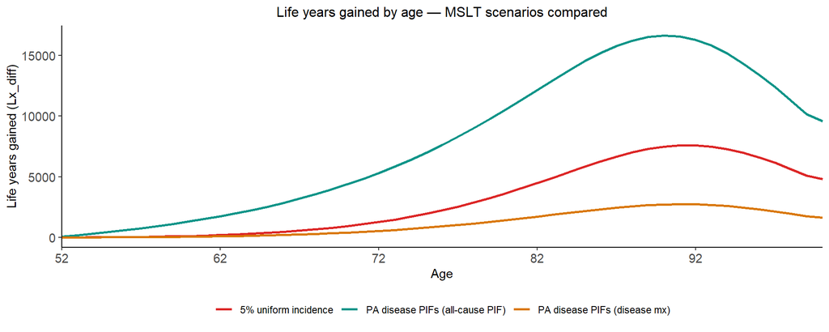

```r
# Compile age profiles for plotting
all_scenarios <- bind_rows(
  output_sc1         %>% transmute(age, value = Lx_diff, scenario = "5% uniform incidence"),
  output_mslt_dis    %>% transmute(age, value = Lx_diff, scenario = "PA disease PIFs (disease mx)"),
  output_mslt_acm    %>% transmute(age, value = Lx_diff, scenario = "PA disease PIFs (all-cause PIF)")
)

ggplot(all_scenarios, aes(x = age, y = value, colour = scenario)) +
  geom_line(linewidth = 1) +
  scale_x_continuous(limits = c(52, 100), breaks = seq(52, 100, 10), expand = c(0, 0)) +
  scale_colour_manual(values = c(
    "5% uniform incidence"             = "#DC2626",
    "PA disease PIFs (disease mx)"     = "#D97706",
    "PA disease PIFs (all-cause PIF)"  = "#0D9488"
  )) +
  labs(title   = "Life years gained by age — MSLT scenarios compared",
       x       = "Age",
       y       = "Life years gained (Lx_diff)",
       colour  = NULL) +
  theme_classic() +
  theme(plot.title      = element_text(size = 12, hjust = 0.5),
        axis.text       = element_text(size = 11),
        axis.title      = element_text(size = 11),
        legend.position = "bottom")
```

**What the comparison teaches**

The three MSLT scenarios produce different results because they enter the model at different points in the causal chain: